# 566hw2

#Download and input the data

```r
library(data.table)
library(tidyverse)
library(leaflet)
library(dplyr)
Individual <- data.table::fread("/Users/jiqingwu/Desktop/566 Introduction to Health Data Science/hw2/chs_individual.csv")
Regional <- data.table::fread("/Users/jiqingwu/Desktop/566 Introduction to Health Data Science/hw2/chs_regional.csv")
```

## Part 1

# 1. Merge the datasets

```r
chs = merge(
  x = Individual, y = Regional,
  by.x = "townname", by.y = "townname",
  all.x = TRUE, all.y = TRUE
)

nrow(Individual)
```

```
## [1] 1200
```

```r
nrow(Regional)
```

```
## [1] 12
```

```r
nrow(chs)
```

```
## [1] 1200
```

#There are 1200 rows in the Individual dataset, 12 rows in Regional dataset and 1200 rows in the merged dataset.

# Impute data using the average within the variables “male” and “hispanic.”

```r
chs[,mean_bmi:=mean(bmi,na.rm=TRUE),by=.(male, hispanic)]
chs[,bmi:=ifelse(is.na(bmi),mean_bmi,bmi)]

chs[,mean_fev:=mean(fev,na.rm=TRUE),by=.(male, hispanic)]
chs[,fev:=ifelse(is.na(fev),mean_fev,fev)]

chs[,mean_gasstove := round(mean(gasstove,na.rm=TRUE)),by=.(male,hispanic)]
chs[,gasstove:=ifelse(is.na(gasstove),mean_gasstove,gasstove)]

chs[,mean_smoke := round(mean(smoke,na.rm=TRUE)),by=.(male,hispanic)]
chs[,smoke:=ifelse(is.na(smoke),mean_smoke,smoke)]
```

# 2. Create obesity level and a summary table

```r
chs$obesity_level <- cut(chs$bmi,
          breaks=c(-Inf, 14, 22, 24, Inf),
          labels=c("underweight","normal","overweight","obese"))

chs %>% group_by(obesity_level) %>%
  summarize(Min = min(bmi, na.rm = TRUE), Max = max(bmi, na.rm = TRUE), Count=n()) %>%
  filter(!is.na(obesity_level))
```

```
## # A tibble: 4 x 4
##   obesity_level   Min   Max Count
##   <fct>         <dbl> <dbl> <int>
## 1 underweight    11.3  14.0    35
## 2 normal         14.0  22.0   975
## 3 overweight     22.0  24.0    87
## 4 obese          24.0  41.3   103
```

# 3. Create smoke gas exposure

```r
chs$smoke_log = as.logical(chs$smoke)
chs$gasstove_log = as.logical(chs$gasstove)

chs$smoke_gas_exposure[!chs$smoke_log & !chs$gasstove_log] <-"no smoke or gas exposure"
chs$smoke_gas_exposure[!chs$smoke_log & chs$gasstove_log] <-"gas exposure"
chs$smoke_gas_exposure[chs$smoke_log & !chs$gasstove_log] <-"smoke exposure"
chs$smoke_gas_exposure[chs$smoke_log & chs$gasstove_log] <-"smoke and gas exposure"
```

# 4. Create four summary tables

```r
# by town
chs[, .(
  fev_avg = mean(fev, na.rm = TRUE),
  fev_sd = sd(fev, na.rm = TRUE),
  asthma_prop = paste0(round(100*sum(asthma, na.rm = TRUE)/length(asthma), 2), '%'),
  non_asthma_prop = paste0(round(100-100*sum(asthma, na.rm = TRUE)/length(asthma), 2), '%')
),
by = townname
]
```

```
##          townname  fev_avg   fev_sd asthma_prop non_asthma_prop
##  1:        Alpine 2087.101 291.1768         11%             89%
##  2:    Atascadero 2075.897 324.0935         25%             75%
##  3: Lake Elsinore 2038.849 303.6956         12%             88%
##  4:  Lake Gregory 2084.700 319.9593         15%             85%
##  5:     Lancaster 2003.044 317.1298         16%             84%
##  6:        Lompoc 2034.354 351.0454         11%             89%
##  7:    Long Beach 1985.861 319.4625         13%             87%
##  8:     Mira Loma 1985.202 324.9634         15%             85%
##  9:     Riverside 1989.881 277.5065         11%             89%
## 10:     San Dimas 2026.794 318.7845         17%             83%
## 11:   Santa Maria 2025.750 312.1725         13%             87%
## 12:        Upland 2024.266 343.1637         12%             88%
```

```r
# male
chs[, .(
  fev_avg = mean(fev, na.rm = TRUE),
  fev_sd = sd(fev, na.rm = TRUE),
  asthma_prop = paste0(round(100*sum(asthma, na.rm = TRUE)/length(asthma), 2), '%'),
  non_asthma_prop = paste0(round(100-100*sum(asthma, na.rm = TRUE)/length(asthma), 2), '%')
),
by = male
]
```

```
##    male  fev_avg   fev_sd asthma_prop non_asthma_prop
## 1:    0 1958.911 311.9181       11.8%           88.2%
## 2:    1 2103.787 307.5123      16.78%          83.22%
```

```r
# obesity level
chs[, .(
  fev_avg = mean(fev, na.rm = TRUE),
  fev_sd = sd(fev, na.rm = TRUE),
  asthma_prop = paste0(round(100*sum(asthma, na.rm = TRUE)/length(asthma), 2), '%'),
  non_asthma_prop = paste0(round(100-100*sum(asthma, na.rm = TRUE)/length(asthma), 2), '%')
),
by = obesity_level
] %>% filter(!is.na(obesity_level))
```

```
##    obesity_level  fev_avg   fev_sd asthma_prop non_asthma_prop
## 1:        normal 1999.794 295.1964      13.64%          86.36%
## 2:    overweight 2224.322 317.4261      16.09%          83.91%
## 3:         obese 2266.154 325.4710      20.39%          79.61%
## 4:   underweight 1698.327 303.3983       8.57%          91.43%
```

```r
# smoke_gas_exposure
chs[, .(
  fev_avg = mean(fev, na.rm = TRUE),
  fev_sd = sd(fev, na.rm = TRUE),
  asthma_prop = paste0(round(100*sum(asthma, na.rm = TRUE)/length(asthma), 2), '%'),
  non_asthma_prop = paste0(round(100-100*sum(asthma, na.rm = TRUE)/length(asthma), 2), '%')
),
by = smoke_gas_exposure
]%>% filter(!is.na(smoke_gas_exposure))
```

```
##          smoke_gas_exposure  fev_avg   fev_sd asthma_prop non_asthma_prop
## 1: no smoke or gas exposure 2056.693 328.7843      14.16%          85.84%
## 2:           smoke exposure 2055.714 295.6475      16.67%          83.33%
## 3:             gas exposure 2022.671 319.3449      14.54%          85.46%
## 4:   smoke and gas exposure 2024.778 300.6313      12.34%          87.66%
```

## Part 2

# Check the main variables

```r
dim(chs)
```

```
## [1] 1200   57
```

```r
head(chs)
```

```
##    townname sid male race hispanic    agepft height weight      bmi asthma
## 1:   Alpine 835    0    W        0 10.099932    143     69 15.33749      0
## 2:   Alpine 838    0    O        1  9.486653    133     62 15.93183      0
## 3:   Alpine 839    0    M        1 10.053388    142     86 19.38649      0
## 4:   Alpine 840    0    W        0  9.965777    146     78 16.63283      0
## 5:   Alpine 841    1    W        1 10.548939    150     78 15.75758      0
## 6:   Alpine 842    1    M        1  9.489391    139     65 15.29189      0
##    active_asthma father_asthma mother_asthma wheeze hayfever allergy
## 1:             0             0             0      0        0       1
## 2:             0             0             0      0        0       0
## 3:             0             0             1      1        1       1
## 4:             0             0             0      0        0       0
## 5:             0             0             0      0        0       0
## 6:             0             0             0      1        0       0
##    educ_parent smoke pets gasstove      fev      fvc     mmef pm25_mass
```

[output cut: 34 more lines]

```r
tail(chs)
```

```
##    townname  sid male race hispanic    agepft height weight      bmi asthma
## 1:   Upland 1866    0    O        1  9.806982    139     60 14.11559      0
## 2:   Upland 1867    0    M        1  9.618070    140     71 16.46568      0
## 3:   Upland 2031    1    W        0  9.798768    135     83 20.70084      0
## 4:   Upland 2032    1    W        0  9.549624    137     59 14.28855      0
## 5:   Upland 2033    0    M        0 10.121834    130     67 18.02044      0
## 6:   Upland 2053    0    W        0        NA     NA     NA 18.05281      0
##    active_asthma father_asthma mother_asthma wheeze hayfever allergy
## 1:             0            NA             0      0       NA      NA
## 2:             0             1             0      0        0       0
## 3:             0             0             0      1        0       1
## 4:             0             0             1      1        1       1
## 5:             1             0             0      1        1       0
## 6:             0             0             0      0        0       0
##    educ_parent smoke pets gasstove      fev      fvc     mmef pm25_mass
```

[output cut: 34 more lines]

```r
str(chs)
```

```
## Classes 'data.table' and 'data.frame':   1200 obs. of  57 variables:
##  $ townname          : chr  "Alpine" "Alpine" "Alpine" "Alpine" ...
##  $ sid               : int  835 838 839 840 841 842 843 844 847 849 ...
##  $ male              : int  0 0 0 0 1 1 1 1 1 1 ...
##  $ race              : chr  "W" "O" "M" "W" ...
##  $ hispanic          : int  0 1 1 0 1 1 0 1 0 0 ...
##  $ agepft            : num  10.1 9.49 10.05 9.97 10.55 ...
##  $ height            : int  143 133 142 146 150 139 149 143 137 147 ...
##  $ weight            : int  69 62 86 78 78 65 98 65 69 112 ...
##  $ bmi               : num  15.3 15.9 19.4 16.6 15.8 ...
##  $ asthma            : int  0 0 0 0 0 0 0 NA 0 0 ...
##  $ active_asthma     : int  0 0 0 0 0 0 0 0 0 0 ...
##  $ father_asthma     : int  0 0 0 0 0 0 0 NA 0 1 ...
##  $ mother_asthma     : int  0 0 1 0 0 0 0 NA 0 0 ...
##  $ wheeze            : int  0 0 1 0 0 1 1 NA 0 1 ...
```

[output cut: 45 more lines]

```r
summary(chs$bmi)
```

```
##    Min. 1st Qu.  Median    Mean 3rd Qu.    Max.
##   11.30   15.96   17.81   18.50   19.99   41.27
```

```r
summary(chs$fev)
```

```
##    Min. 1st Qu.  Median    Mean 3rd Qu.    Max.
##   984.8  1827.6  2016.4  2030.1  2223.6  3323.7
```

```r
summary(chs$pm25_mass)
```

```
##    Min. 1st Qu.  Median    Mean 3rd Qu.    Max.
##   5.960   7.615  10.545  14.362  20.988  29.970
```

```r
table(chs$smoke_gas_exposure)
```

```
##
##             gas exposure no smoke or gas exposure   smoke and gas exposure
##                      791                      219                      154
##           smoke exposure
##                       36
```

# Check for the dimensions, headers, footers. Missing values are imputed using mean value at the begining. There is no implausible values in these four main variables.

# 1. Facet plot showing scatterplots with regression lines of BMI vs FEV by “townname”.

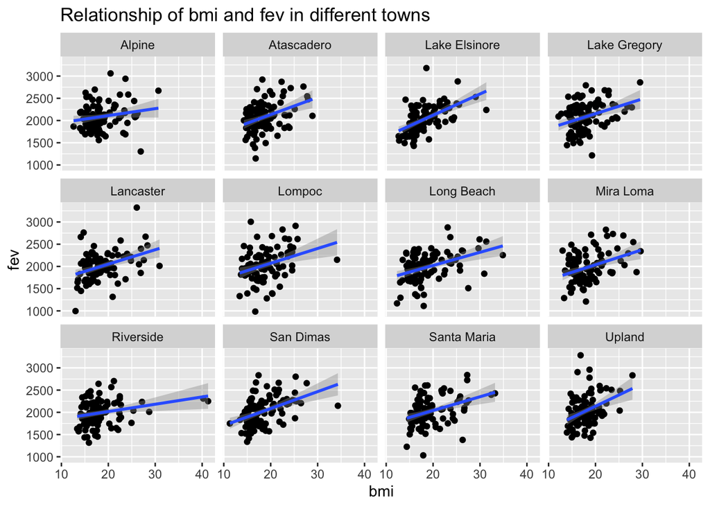

```r
chs %>%
  filter(!(townname %in% NA)) %>%
  ggplot(mapping = aes(x = bmi, y = fev)) +
  geom_point() +
  geom_smooth(method = 'lm', formula = y~x) +
  facet_wrap(~ townname) +
  ggtitle("Relationship of bmi and fev in different towns")
```

# 2. Stacked histograms of FEV by BMI category and FEV by smoke/gas exposure. Use different color schemes than the ggplot default.

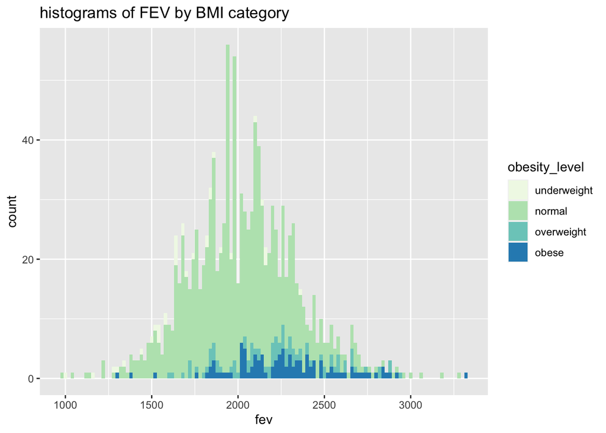

```r
# by obesity level
chs %>%
  #filter(!(obesity_level %in% NA)) %>%
ggplot(diamonds, mapping = aes(x = fev, fill = obesity_level)) +
  scale_fill_brewer(palette = "GnBu") +
  geom_histogram(binwidth = 20) +
  labs(title="histograms of FEV by BMI category")
```

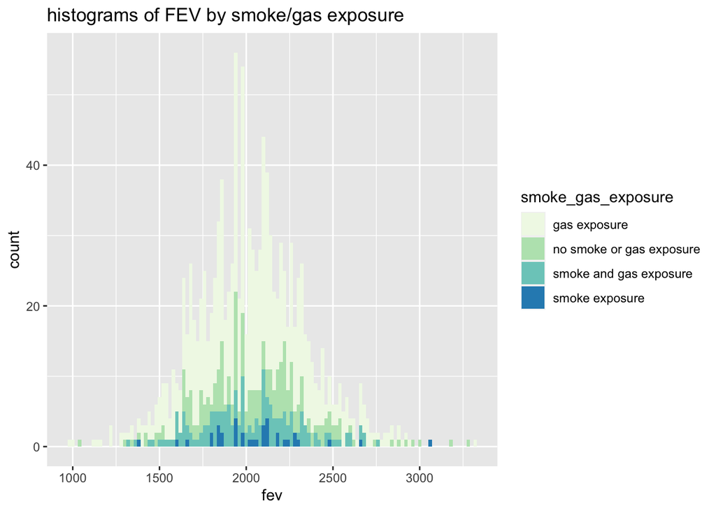

```r
# by smoke/gas exposure
chs %>%
  #filter(!(smoke_gas_exposure %in% NA)) %>%
ggplot(diamonds, mapping = aes(x = fev, fill = smoke_gas_exposure)) +
  scale_fill_brewer(palette = "GnBu") +
  geom_histogram(binwidth = 20) +
  labs(title="histograms of FEV by smoke/gas exposure")
```

# People with a higher fev seems more likely to have a higher bmi while people with different smoke and gas exposure situation seems to have a more uniform distribution in fev. In other words, bmi has a positive relationship with fev, whille gas/smoke exposure does not affect fev.

# 3. Barchart of BMI by smoke/gas exposure.

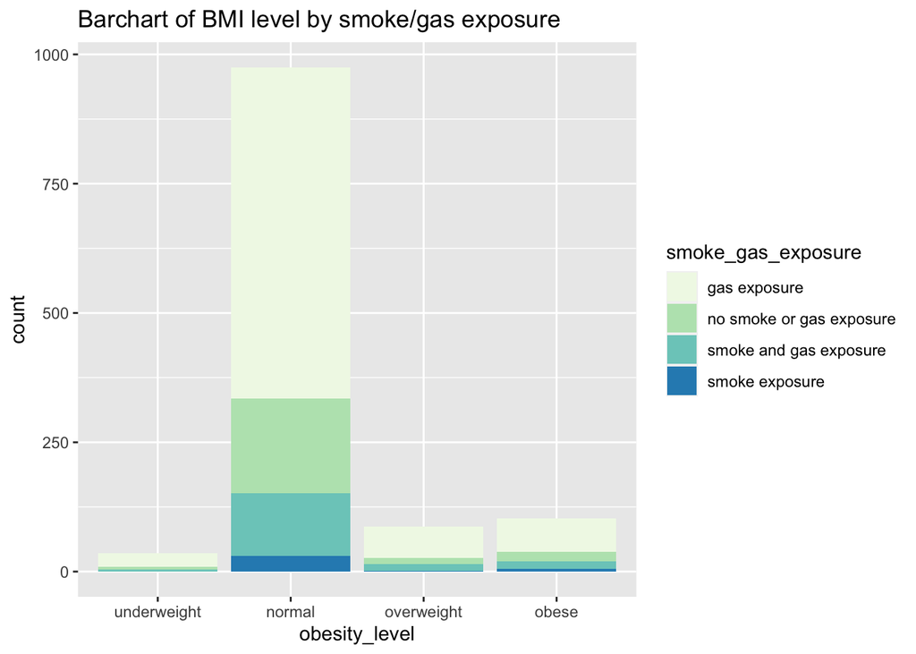

```r
chs %>%
  #filter(!(smoke_gas_exposure %in% NA)) %>%
  #filter(!(obesity_level %in% NA)) %>%
  ggplot() +
  geom_bar(mapping = aes(x = obesity_level, fill = smoke_gas_exposure)) +
  scale_fill_brewer(palette = "GnBu") +
   labs(title="Barchart of BMI level by smoke/gas exposure")
```

# It seems that a larger proportions of obese people are exposured to smoke. Most of people are exposed to gas, and this does not affect obesity level.

# 4. Statistical summary graphs of FEV by BMI and FEV by smoke/gas exposure category.

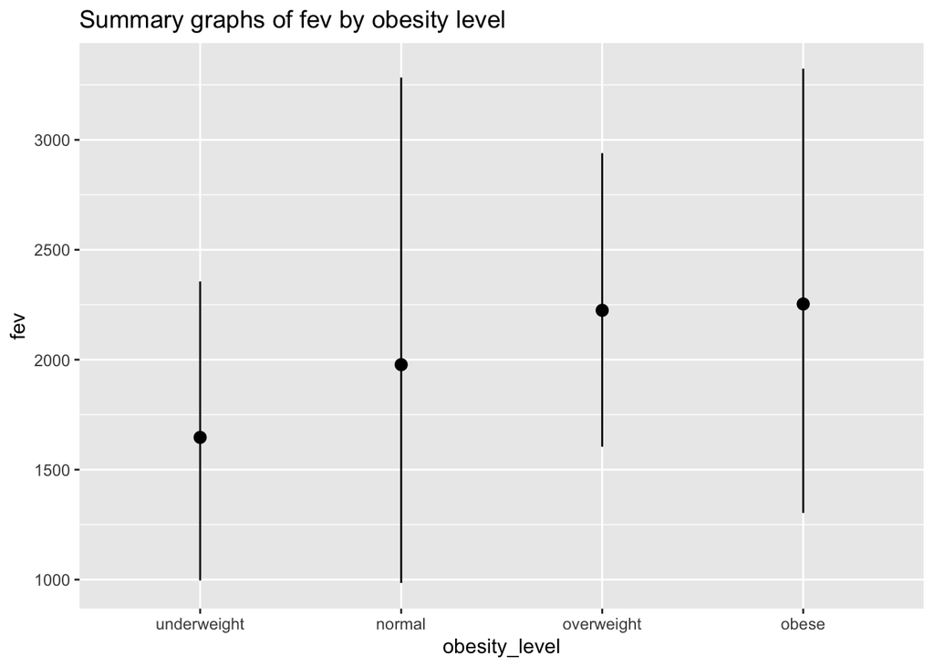

```r
# by bmi level
chs %>%
  #filter(!(obesity_level %in% NA)) %>%
  ggplot() +
  stat_summary(mapping = aes(x = obesity_level, y = fev),
               fun.min = min,
               fun.max = max,
               fun = median) +
labs(title="Summary graphs of fev by obesity level")
```

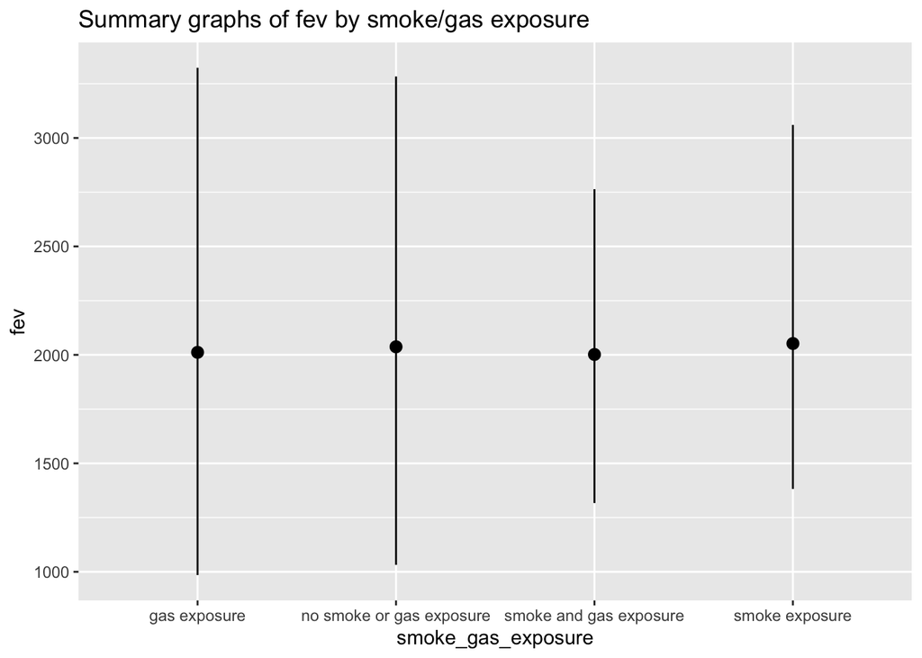

```r
# by smoke/gas exposure
chs %>%
  #filter(!(smoke_gas_exposure %in% NA)) %>%
  ggplot() +
  stat_summary(mapping = aes(x = smoke_gas_exposure, y = fev),
               fun.min = min,
               fun.max = max,
               fun = median) +
  labs(title="Summary graphs of fev by smoke/gas exposure")
```

# From the summary graphs, people with a higher bmi level are more likely to have a higher fev while people with different gas/smoke exposure situation seem to have a similar fev.

# 5. A leaflet map showing the concentrations of PM2.5 mass in each of the CHS communities.

```r
pm_pal<-colorNumeric(c("blue","purple","red"), domain=chs$pm25_mass)

leaflet(chs) %>%
  addProviderTiles("OpenStreetMap") %>%
  addCircles(lat=~lat, lng=~lon, color=~pm_pal(pm25_mass),opacity=1,fillOpacity=1,radius=100) %>%
  addLegend("bottomleft", pal=pm_pal, values=chs$pm25_mass, title="PM 2.5 concentration in CHS commuities", opacity=1)
```

[interactive chart not shown]

# The map shows that red dots (area with higher PM 2.5 concentrations) are concentrated near the city (e.g. LA).

# 6. Choose a visualization to examine whether PM2.5 mass is associated with FEV.

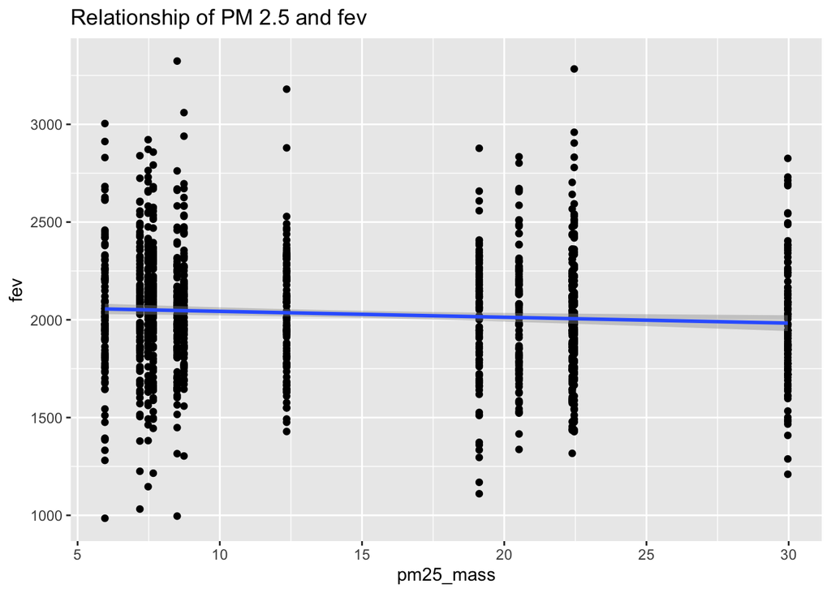

```r
chs %>%
  ggplot(mapping = aes(x = pm25_mass, y = fev)) +
  geom_point() +
  geom_smooth(method = 'lm', formula = y~x) +
  ggtitle("Relationship of PM 2.5 and fev")
```

```r
cor.test(chs$pm25_mass, chs$fev)
```

```
##
##  Pearson's product-moment correlation
##
## data:  chs$pm25_mass and chs$fev
## t = -2.5479, df = 1198, p-value = 0.01096
## alternative hypothesis: true correlation is not equal to 0
## 95 percent confidence interval:
##  -0.12946493 -0.01689373
## sample estimates:
##         cor
## -0.07341317
```

# From the graph above, the regression line shows a slight descending trend, while the change is small. From the correlation test, the p-value=0.01096<0.05. Therefore, the relationship between PM 2.5 and FEV is significant. Correlation coefficient is -0.0734 which indicates a negative relationship. As the concentration of PM 2.5 in an area increase, the FEV value would decrease.